# BTEP-R/RStudio-Intro

### Data types in R

- six basic types of atomic vectors:
- doubles, integers, characters, logicals, complex, and raw
- last two are not very important and we will not discuss further

```r
complex(1,2)
```

```
## [1] 2+0i
```

```r
raw(2) # bytes of numbers
```

```
## [1] 00 00
```

#### Integer variables

```r
ia <- 1L
ia1 <- 1
class(ia)
```

```
## [1] "integer"
```

```r
typeof(ia)
```

```
## [1] "integer"
```

```r
class(ia1)
```

```
## [1] "numeric"
```

```r
typeof(ia1)
```

```
## [1] "double"
```

#### Double variables

```r
ra <- runif(10)
typeof(ra)
```

```
## [1] "double"
```

```r
class(ra)
```

```
## [1] "numeric"
```

#### Character variables

```r
ca <- c("Tom", "cat")
typeof(ca)
```

```
## [1] "character"
```

```r
class(ca)
```

```
## [1] "character"
```

#### Let us talk about attributes

```r
ia <- 1L
names(ia) <- "id"
ia
```

```
## id
##  1
```

#### Other types, matrix

```r
M <- matrix(1:6, 3, 2)
dim(M)
```

```
## [1] 3 2
```

```r
args(matrix)
```

```
## function (data = NA, nrow = 1, ncol = 1, byrow = FALSE, dimnames = NULL)
## NULL
```

#### R as a simple calculator

2 * 3

if R doesnt recognize a code, it displays a + and waits for you

```r
2 *
```

Run the following line. you will get an error message. Why?

```r
10 % 5
```

### Everything is a vector object in R

```r
aa <- 22.7

aa = 1 # DO not use not standard

aa + 2
```

```
## [1] 3
```

```r
sqrt(aa+1)
```

```
## [1] 1.414214
```

```r
aa/3
```

```
## [1] 0.3333333
```

```r
ages<-c(1,2,3,4) # another way to create vectors
ages
```

```
## [1] 1 2 3 4
```

```r
ages+3   # ages of kids after 3 years
```

```
## [1] 4 5 6 7
```

```r
         # scalar is a zero vector
ages
```

```
## [1] 1 2 3 4
```

RStudio environment pane displayes the stored variables

### What are acceptable and non acceptable variable names in R ?

Acceptable (Yes) and non-acceptable (No) Variable Names

| No | Yes |
| --- | --- |
| 1run | run1 |
| b$ | b |
| ^mean | mean |
| !var1 | var1 |

### Variable names are case-sensitive and can be over-written

```r
var1 <- 2
VAR1 <- 1
(var1 <- 100) # overwrite
```

```
## [1] 100
```

### List the variables

Hint: You can also use the Global Environment pane in RStudio for extracting this information

```r
ls() # to see what variables you have so far
```

```
##  [1] "aa"   "ages" "ca"   "df"   "ia"   "ia1"  "M"    "ncsv" "No"   "ra"
## [11] "tcsv" "var1" "VAR1" "Yes"
```

```r
list.files()  # to see the list of files
```

```
##  [1] "BTEP-Class-TidyingData-05-16-2017.md"
##  [2] "Data"
##  [3] "Images"
##  [4] "MyStuff"
##  [5] "R-RStudio-InstallationInstrns"
##  [6] "Readme"
##  [7] "README.md"
##  [8] "TidyingData-Date-Time.md"
##  [9] "TidyingData-Date-Time.Rmd"
## [10] "TidyingData-figure"
## [11] "TidyingData-FinalExercise.md"
## [12] "TidyingData-FinalExercise.Rmd"
## [13] "TidyingData-Handson.md"
## [14] "TidyingData-Handson.Rmd"
## [15] "TidyingData-R-RStudio-Intro.md"
## [16] "TidyingData-R-RStudio-Intro.Rmd"
## [17] "TidyingData-R-RStudio-Intro_files"
## [18] "TidyingData-RegEx.md"
## [19] "TidyingData-RegEx.Rmd"
## [20] "TidyingData-Rmd-Intro.md"
## [21] "TidyingData-Rmd-Intro.Rmd"
## [22] "TidyingData.md"
## [23] "TidyingData.Rpres"
```

### For the following section, let us use a 6-sided die and do some Data analysis.

First let us create a die object

```r
die <- 1:6 # 6 sided die
```

### Let us do some Math with our Die

Notice the vector math

```r
die + 2
```

```
## [1] 3 4 5 6 7 8
```

```r
die/2
```

```
## [1] 0.5 1.0 1.5 2.0 2.5 3.0
```

```r
die * die
```

```
## [1]  1  4  9 16 25 36
```

### Let us watch out for recycling

```r
die + 1:2
```

```
## [1] 2 4 4 6 6 8
```

### Let us explore built-in functions using our Die

```r
sum(die)
```

```
## [1] 21
```

```r
mean(die)
```

```
## [1] 3.5
```

### How to get help in R?

```r
?sum
```

### Stored constants

```r
pi # not PI
```

```
## [1] 3.141593
```

### let us round numbers

```r
round(pi, 10) # what happened here
```

```
## [1] 3.141593
```

```r
round(pi, 2)
```

```
## [1] 3.14
```

```r
round(pi, digits = 9)
```

```
## [1] 3.141593
```

### How to find the arguments for a built-in function?

```r
args(round)
```

```
## function (x, digits = 0)
## NULL
```

```r
args(plot)
```

```
## function (x, y, ...)
## NULL
```

### R-basic Exercise-1

- Find out what the function sample does? let us sample a die by rolling 3 times in R.

#### What is the issue with the following command?

```r
sample(die, size = 7)
```

### Can we change the default of sample function?

```r
p <- c(rep(0.01,5), 0.95)
sample(x = die, size = 10, replace = TRUE, prob = p)
```

```
##  [1] 6 6 6 6 6 6 6 6 6 6
```

### Do we always have to use the arguments name? What if we dont?

```r
sample(die, 10, replace = TRUE)
```

```
##  [1] 2 4 1 6 5 5 2 3 5 5
```

```r
sample(die, 10, TRUE) #  define them explicitely
```

```
##  [1] 6 3 4 1 1 3 5 5 3 1
```

```r
sample(x = die, size = 6, replace = TRUE)
```

```
## [1] 5 3 6 1 3 2
```

### Let us roll the die multiple times

```r
# First roll
sample(x = die, size = 2, replace = TRUE) # def prob
```

```
## [1] 1 2
```

```r
# one more roll
sample(x = die, size = 2, replace = TRUE) # def prob
```

```
## [1] 6 3
```

### Random numbers

```r
unif_rand <- runif(10)
args(round)
```

```
## function (x, digits = 0)
## NULL
```

### Function in R

- Function constructor (like C++) has three parts
- 1. name
- 2. body (of code)
- 3. arguments
- function() { ### }

### Let us build a function

```r
dist <- function(a, b) {
  distsq <- sum( (b - a)^2 )
  sqrt(distsq)
}
```

Let us call the function with inputs

```r
a <- c(1,2)
b <- c(3,3)

dist(a,b)
```

```
## [1] 2.236068
```

### Now let us turn the following lines into a function in RStudio

```r
#Use RStudio to turn the following line into a function called dist2

distsq <- sum( (b - a)^2 )
sqrt(distsq)
```

```
## [1] 2.236068
```

### Installing and using packages in R

- R comes with core packages (basic). There are several packages available for R (Ex. Tidyverse)
- How can I install a package? `install.packages(“foreign”) # to install foreign package`
- After installation, you have load the package, using the following command

  ```
  library(foreign)
  help(package=foreign)
  ```

After using a package, use

```
detach(foreign)
```

to remove a package (ex. foreign package) from the workspace.

Use

```
 SessionInfo()
```

to get a detailed description of the attached packages and R session. R commands can be either typed or loaded from a file using source command.

Here is an example of installing a package called randomForest and updating package(s)

```r
install.packages("randomForest")
library(randomForest)
## multiple packages
update.packages(c("randomForest","tidyverse"))
```

### Debugging in R

```r
mysum <- function(a,b) {
  sum( (bb - a)^2 )
}

dist <- function(a, b) {
  distsq <- mysum(a,b)
  sqrt(distsq)
}

# use of RStudio bebug or traceback function
dist(a,b)
```

### plots

Here we will explore the basic plots in R. Watch out for future graphics workshop using R, where we will explore the new and powerful ggplot function For now, we will focus on simple plots.

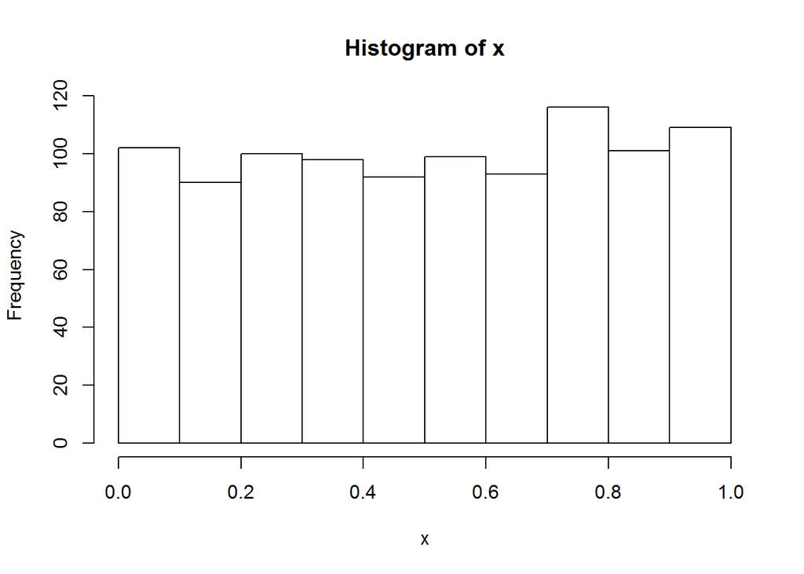

```r
x <- runif(1000)
hist(x)
```

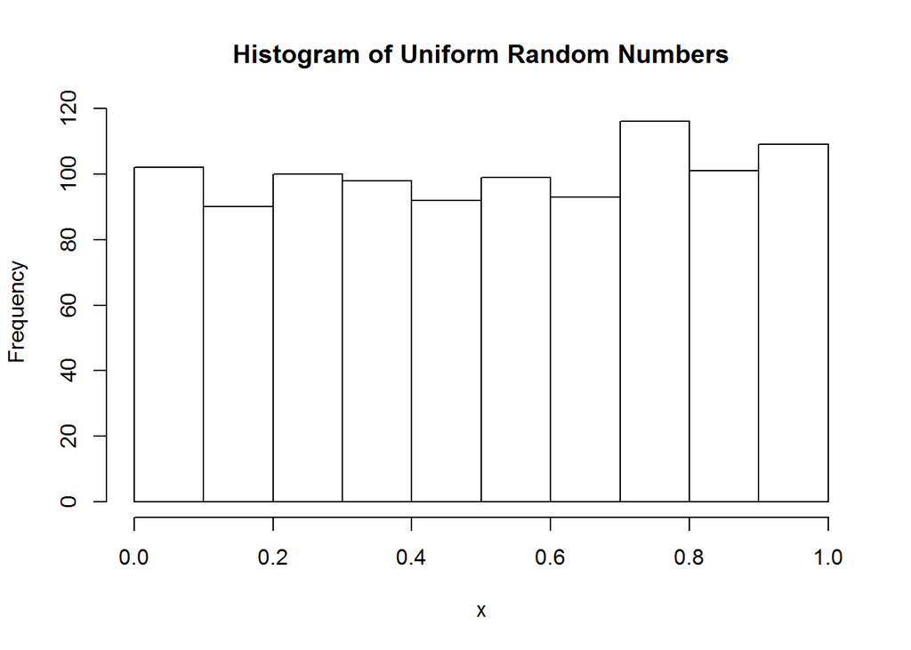

```r
hist(x, main = "Histogram of Uniform Random Numbers")
```

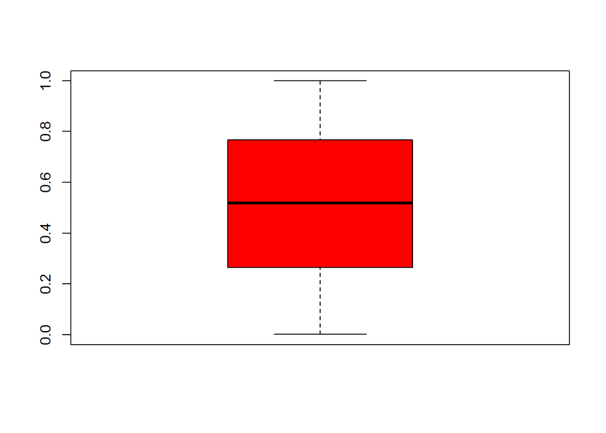

```r
boxplot(x, col = "red")
```

### Read and Write, compressed file

write.csv(lcancer, file = bzfile(“data/lcaner.csv.bz2”), row.names = FALSE)

### Some useful functions

Let us use the cars dataset to show some important R commands

```r
str(cars)
```

```
## 'data.frame':    50 obs. of  2 variables:
##  $ speed: num  4 4 7 7 8 9 10 10 10 11 ...
##  $ dist : num  2 10 4 22 16 10 18 26 34 17 ...
```